# Camonsertib rBA - BP44676

### 0.2.3 Derived PK Data from Repare

Current data was transferred in batch 31

```r
nca_pk_dat_repare <- read_excel(path = '../../0_Common/10_Data/3_Data_Transferred/4_Batch-31-20230112/20230106 - Final Parameters Pivoted_120 patients_Roche (1).xlsx', sheet='Sheet1')
nca_pk_dat_repare$USUBJID <- nca_pk_dat_repare$USUBJID %>% sapply(FUN=function(x) {
  paste0('RP-3500-01-', substr(x = x, start=1, stop=4), '-',substr(x = x, start=5, stop=8))
})

nca_pk_dat_repare$AUC0_12 <- nca_pk_dat_repare$`AUC0-12`
nca_pk_dat_repare <- nca_pk_dat_repare %>% as.data.frame

# extract only module 1 and 2 patients
nca_pk_dat_repare <- nca_pk_dat_repare %>% filter(USUBJID %>% substr(x=., start=12, stop=12) %in% c('1', '2'))

# Remove data before dosing
# nca_pk_dat_repare <- nca_pk_dat_repare %>% filter(Day>0) # does not really matter
nca_pk_dat_repare_160 <- nca_pk_dat_repare %>% dplyr::filter(Dose =='160')

# Check if all pts in repare derivation is in Anh's derivation
nca_pk_dat_repare_160$USUBJID %>% unique %>% setdiff(x=., y=pc160_id) %>% kable
```

| x |
| --- |
| RP-3500-01-1001-0007 |

```r
nca_pk_dat_repare_160$USUBJID %>% unique %>% setdiff(y=., x=pc160_id) %>% kable
```

| x |
| --- |
| RP-3500-01-1001-0016 |
| RP-3500-01-1001-0078 |
| RP-3500-01-1001-0153 |
| RP-3500-01-1001-0208 |
| RP-3500-01-1001-0312 |
| RP-3500-01-1002-0161 |
| RP-3500-01-1002-0297 |
| RP-3500-01-1002-0323 |
| RP-3500-01-1003-0300 |
| RP-3500-01-1005-0248 |
| RP-3500-01-1005-0305 |
| RP-3500-01-1006-0285 |
| RP-3500-01-1006-0332 |

```r
nca_pk_dat_repare_160$USUBJID %>% unique %>% setdiff(x=., y=nca_pk_dat_160_id) %>% kable
```

| x |
| --- |
| RP-3500-01-1001-0007 |
| RP-3500-01-1001-0092 |
| RP-3500-01-1001-0146 |
| RP-3500-01-1001-0150 |
| RP-3500-01-1001-0154 |

```r
nca_pk_dat_repare_160$USUBJID %>% unique %>% setdiff(y=., x=nca_pk_dat_160_id) %>% kable
```

| x |
| --- |
| RP-3500-01-1001-0208 |
| RP-3500-01-1001-0312 |
| RP-3500-01-1002-0161 |
| RP-3500-01-1002-0297 |
| RP-3500-01-1002-0323 |
| RP-3500-01-1003-0300 |
| RP-3500-01-1005-0248 |
| RP-3500-01-1005-0305 |
| RP-3500-01-1006-0285 |
| RP-3500-01-1006-0332 |
| RP-3500-01-3001-0198 |
| RP-3500-01-3001-0317 |
| RP-3500-01-3002-0201 |
| RP-3500-01-3002-0330 |
| RP-3500-01-3003-0061 |
| RP-3500-01-3003-0100 |
| RP-3500-01-3003-0145 |
| RP-3500-01-3003-0180 |
| RP-3500-01-3003-0182 |
| RP-3500-01-3003-0184 |
| RP-3500-01-3003-0194 |
| RP-3500-01-3003-0196 |
| RP-3500-01-3003-0206 |
| RP-3500-01-3003-0211 |
| RP-3500-01-3003-0217 |
| RP-3500-01-3003-0227 |
| RP-3500-01-3003-0270 |
| RP-3500-01-3003-0279 |
| RP-3500-01-3003-0302 |
| RP-3500-01-3003-0319 |
| RP-3500-01-4001-0010 |
| RP-3500-01-4001-0177 |
| RP-3500-01-4001-0240 |
| RP-3500-01-4001-0267 |

## 0.3 Trial Design

- For most recent details see slide 8 or 11 of this deck: https://docs.google.com/presentation/d/1O0r1Mx-feQiC3BfKAdGQg2lojBAn-Fml/edit#slide=id.p2
- Primary endpoints: $AUC_{\infty}$, $AUC_{\text{last}}$ and $C_{\max}$

## 0.4 Estimation of Primary Endpoints for Each Patients and the Respective CV

### 0.4.1 Summary of Relevant PK Parameters

#### 0.4.1.1 Roche derivation

```r
table1(~AUCINF_obs%>%as.numeric+AUCINF_pred%>%as.numeric+AUCall%>%as.numeric+AUClast%>%as.numeric+Cmax%>%as.numeric+Clast%>%as.numeric, data=nca_pk_dat_160)
```

|  | Overall (N=215) |
| --- | --- |
| AUCINF_obs %>% as.numeric |  |
| Mean (SD) | 61100 (34800) |
| Median [Min, Max] | 52500 [11800, 210000] |
| Missing | 8 (3.7%) |
| AUCINF_pred %>% as.numeric |  |
| Mean (SD) | 61100 (34800) |
| Median [Min, Max] | 52400 [11800, 210000] |
| Missing | 8 (3.7%) |
| AUCall %>% as.numeric |  |
| Mean (SD) | 53900 (28000) |
| Median [Min, Max] | 46400 [11400, 169000] |
| AUClast %>% as.numeric |  |
| Mean (SD) | 53900 (28000) |
| Median [Min, Max] | 46400 [11400, 169000] |
| Cmax %>% as.numeric |  |
| Mean (SD) | 8140 (3250) |
| Median [Min, Max] | 7730 [1900, 24500] |
| Clast %>% as.numeric |  |
| Mean (SD) | 628 (849) |
| Median [Min, Max] | 308 [17.0, 5630] |

#### 0.4.1.2 Repare derivation

```r
table1(~AUCINF_obs%>%as.numeric+AUC0_12%>%as.numeric+AUClast%>%as.numeric+Cmax%>%as.numeric, data=nca_pk_dat_repare_160)
```

|  | Overall (N=120) |
| --- | --- |
| AUCINF_obs %>% as.numeric |  |
| Mean (SD) | 58.3 (36.9) |
| Median [Min, Max] | 47.2 [17.9, 194] |
| Missing | 5 (4.2%) |
| AUC0_12 %>% as.numeric |  |
| Mean (SD) | 40.8 (20.6) |
| Median [Min, Max] | 35.6 [1.89, 114] |
| Missing | 3 (2.5%) |
| AUClast %>% as.numeric |  |
| Mean (SD) | 51.4 (29.4) |
| Median [Min, Max] | 42.4 [16.3, 154] |
| Missing | 1 (0.8%) |
| Cmax %>% as.numeric |  |
| Mean (SD) | 7.95 (3.43) |
| Median [Min, Max] | 7.74 [0.115, 24.5] |

### 0.4.2 Estimate $AUC_{\infty}$

**Questions**

- Should we use `AUCINF_pred` or `AUCINF_obs`? In any case they are virtually similar as the plot below.

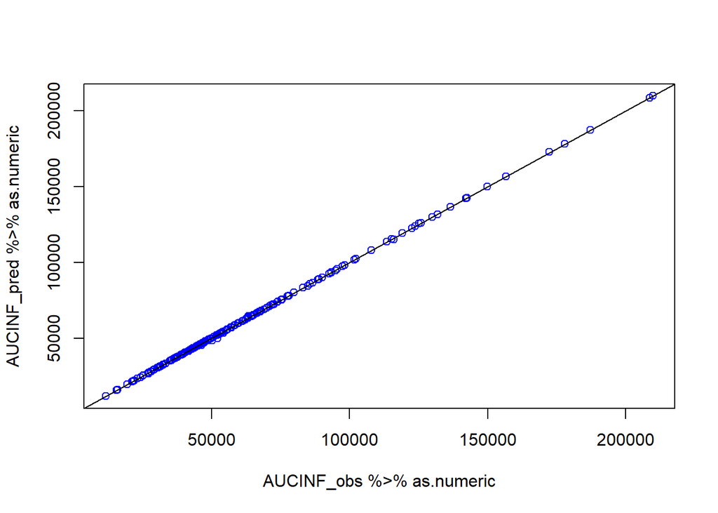

```r
with(nca_pk_dat_160, plot(x = AUCINF_obs %>% as.numeric, y = AUCINF_pred %>% as.numeric, col='blue'))
abline(a=0, b=1)
```

**Estimation**

```r
aucinf_anh <- pc160 %>% group_by(USUBJID, PCRFTDTC_Date) %>% summarise(AUCINF_obs=nca.complete(conc=PCSTRESN,                                     time=((PCDTC%>% as.POSIXct(format="%Y-%m-%dT%H:%M"))-
       (PCDTC[1]%>% as.POSIXct(format="%Y-%m-%dT%H:%M"))) %>% as.numeric/3600
  )$est['AUC to infinity',1]
)
aucinf_anh <- aucinf_anh %>% filter(AUCINF_obs >= 0)

aucinf_anh_fasted <- pc160_fasted %>% group_by(USUBJID, PCRFTDTC_Date) %>% summarise(AUCINF_obs=nca.complete(conc=PCSTRESN,                                     time=((PCDTC%>% as.POSIXct(format="%Y-%m-%dT%H:%M"))-
       (PCDTC[1]%>% as.POSIXct(format="%Y-%m-%dT%H:%M"))) %>% as.numeric/3600
  )$est['AUC to infinity',1]
)
aucinf_anh_fasted <- aucinf_anh_fasted %>% filter(AUCINF_obs >= 0)
```

**Check if data is normally or log-normally distributed**

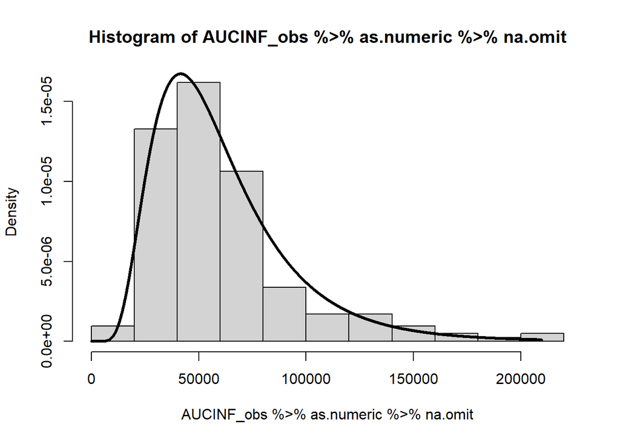

```r
# For Roche PK team derived data
with(nca_pk_dat_160, {
  x <- AUCINF_obs %>% as.numeric %>% na.omit
  hist(AUCINF_obs %>% as.numeric %>% na.omit, freq=F)
  fit<-fitdistr(x,"log-normal")$estimate
  lines(dlnorm(0:max(x),fit[1],fit[2]), lwd=3)
  }
)
```

```r
nca_pk_dat_160$AUCINF_obs_log <- nca_pk_dat_160$AUCINF_obs %>% as.numeric %>% log
```

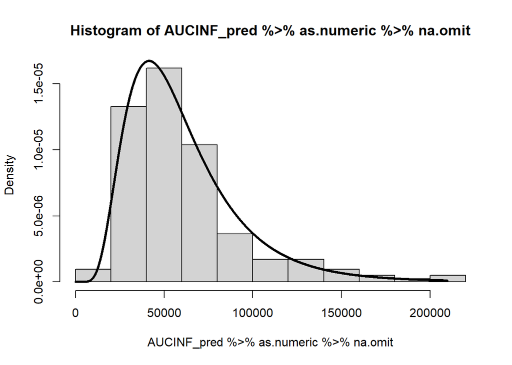

```r
with(nca_pk_dat_160, {
  x <- AUCINF_pred %>% as.numeric %>% na.omit
  hist(AUCINF_pred %>% as.numeric %>% na.omit, freq=F)
  fit<-fitdistr(x,"log-normal")$estimate
  lines(dlnorm(0:max(x),fit[1],fit[2]), lwd=3)
  }
)
```

```r
nca_pk_dat_160$AUCINF_pred_log <- nca_pk_dat_160$AUCINF_pred %>% as.numeric %>% log
```

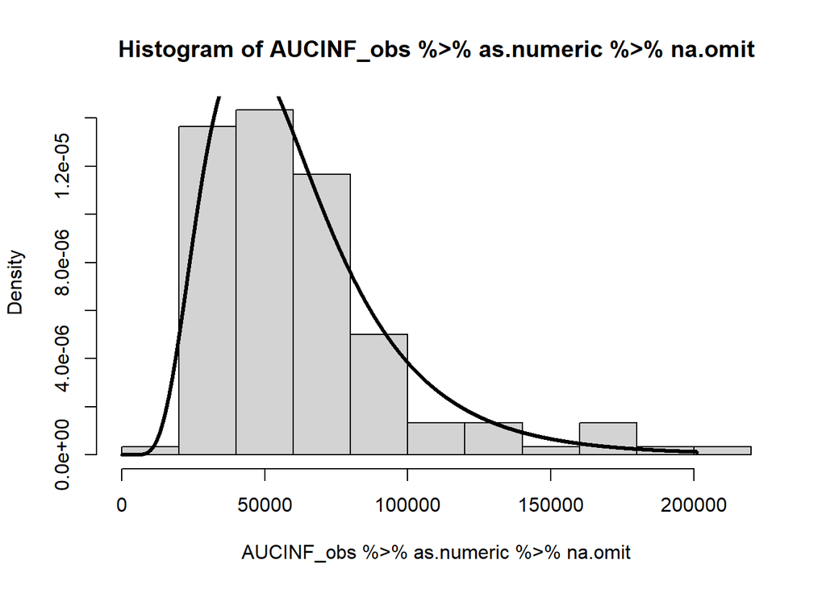

```r
# For self-derived data
with(aucinf_anh, {
  x <- AUCINF_obs %>% as.numeric %>% na.omit
  hist(AUCINF_obs %>% as.numeric %>% na.omit, freq=F)
  fit<-fitdistr(x,"log-normal")$estimate
  lines(dlnorm(0:max(x),fit[1],fit[2]), lwd=3)
  }
)
```

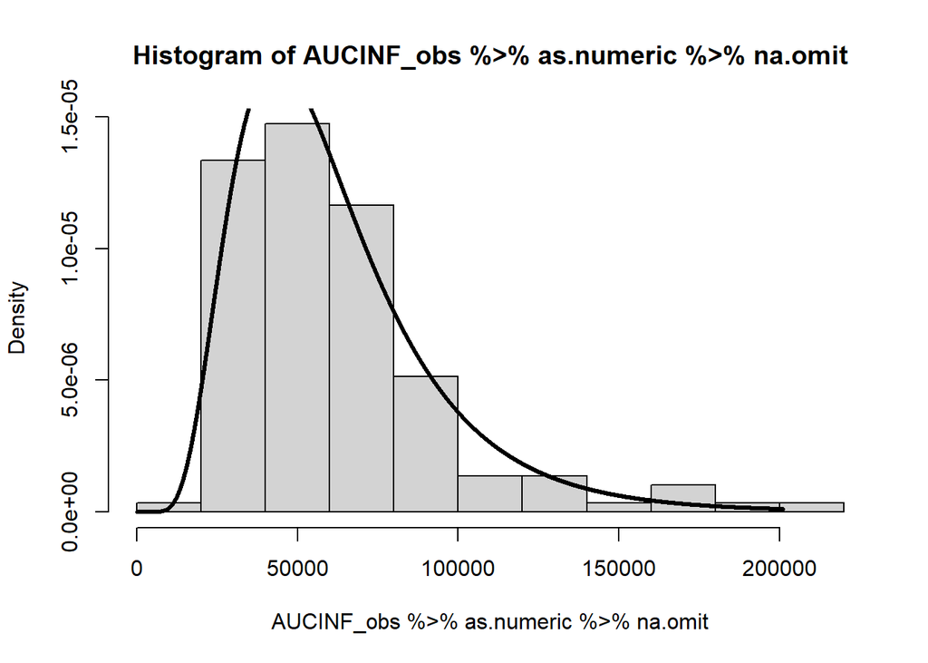

```r
aucinf_anh$AUCINF_obs_log <- aucinf_anh$AUCINF_obs %>% log

with(aucinf_anh_fasted, {
  x <- AUCINF_obs %>% as.numeric %>% na.omit
  hist(AUCINF_obs %>% as.numeric %>% na.omit, freq=F)
  fit<-fitdistr(x,"log-normal")$estimate
  lines(dlnorm(0:max(x),fit[1],fit[2]), lwd=3)
  }
)
```

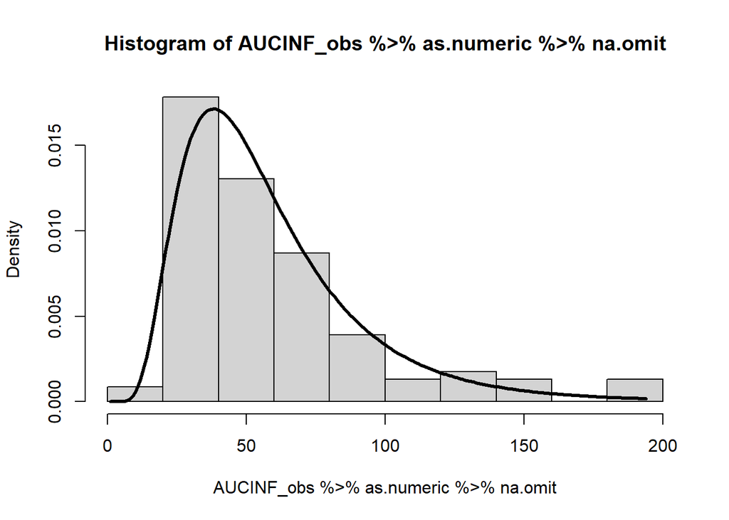

```r
aucinf_anh_fasted$AUCINF_obs_log <- aucinf_anh_fasted$AUCINF_obs %>% log

# For repare-derived data
with(nca_pk_dat_repare_160, {
  x <- AUCINF_obs %>% as.numeric %>% na.omit
  hist(AUCINF_obs %>% as.numeric %>% na.omit, freq=F)
  fit<-fitdistr(x,"log-normal")$estimate
  lines(dlnorm(0:max(x),fit[1],fit[2]), lwd=3)
  }
)
```

```r
nca_pk_dat_repare_160$AUCINF_obs_log <- nca_pk_dat_repare_160$AUCINF_obs %>% as.numeric %>% log
```

**Estimate CV**

```r
# for Roche PK team derived data
tmp_anova <- aov(AUCINF_obs_log ~ USUBJID, data = nca_pk_dat_160)
mse       <- (tmp_anova$residuals ^ 2 %>% sum) / tmp_anova$df.residual

(cv_aucinf_obs_log <- mse2CV(mse))
```

```
## [1] 0.1817233
```

```r
# repeat for AUCIINF_pred
tmp_anova <- aov(AUCINF_pred_log ~ USUBJID, data = nca_pk_dat_160)
mse       <- (tmp_anova$residuals ^ 2 %>% sum) / tmp_anova$df.residual

(cv_aucinf_pred_log <- mse2CV(mse))
```

```
## [1] 0.1820314
```

```r
# repeat for self-derived data
tmp_anova2 <- aov(AUCINF_obs_log ~ USUBJID, data = aucinf_anh)
mse2       <- (tmp_anova2$residuals ^ 2 %>% sum) / tmp_anova2$df.residual

(cv_aucinf_obs_log2 <- mse2CV(mse2))
```

```
## [1] 0.190613
```

```r
tmp_anova2_fasted <- aov(AUCINF_obs_log ~ USUBJID, data = aucinf_anh_fasted)
mse2_fasted       <- (tmp_anova2_fasted$residuals ^ 2 %>% sum) / tmp_anova2_fasted$df.residual

(cv_aucinf_obs_log2_fasted <- mse2CV(mse2_fasted))
```

```
## [1] 0.192443
```

```r
# For self-derived data and consider only pts appearing in repare's pk sets
tmp_anova3 <- aov(AUCINF_obs_log ~ USUBJID, data = aucinf_anh %>% filter(USUBJID %in% (nca_pk_dat_repare_160$USUBJID %>% unique)) )
mse3       <- (tmp_anova3$residuals ^ 2 %>% sum) / tmp_anova3$df.residual

(cv_aucinf_obs_log3 <- mse2CV(mse3))
```

```
## [1] 0.1966822
```

```r
tmp_anova3_fasted <- aov(AUCINF_obs_log ~ USUBJID, data = aucinf_anh_fasted %>% filter(USUBJID %in% (nca_pk_dat_repare_160$USUBJID %>% unique)))
mse3_fasted       <- (tmp_anova3_fasted$residuals ^ 2 %>% sum) / tmp_anova3_fasted$df.residual

(cv_aucinf_obs_log3_fasted <- mse2CV(mse3_fasted))
```

```
## [1] 0.199179
```

```r
# repeat for repare-derived data
tmp_anova <- aov(AUCINF_obs_log ~ USUBJID, data = nca_pk_dat_repare_160)
mse       <- (tmp_anova$residuals ^ 2 %>% sum) / tmp_anova$df.residual

(cv_aucinf_obs_log_repare <- mse2CV(mse))
```

```
## [1] 0.192
```

### 0.4.3 Estimate $AUC_{\text{last}}$

**Questions**

- Should we use `AUClast` or `AUCall`? In any case they are virtually similar as the plot below.

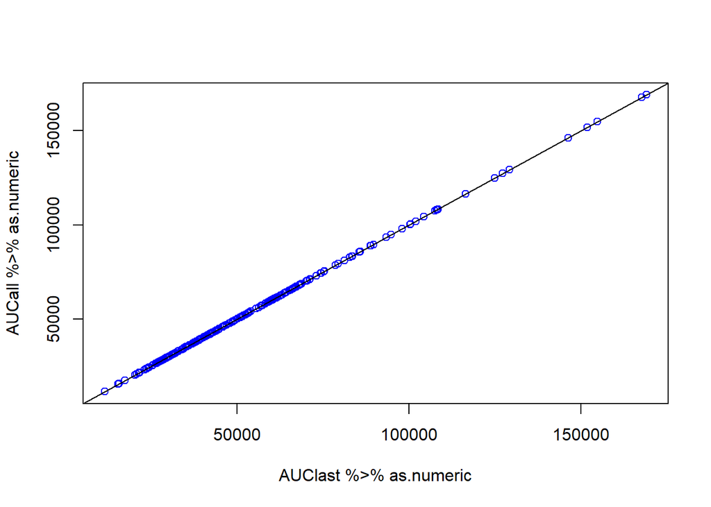

```r
with(nca_pk_dat_160, plot(x = AUClast %>% as.numeric, y = AUCall %>% as.numeric, col='blue'))
abline(a=0, b=1)
```

**Estimation**

```r
auclast_anh <- pc160 %>% group_by(USUBJID, PCRFTDTC_Date) %>% summarise(AUClast=nca.complete(conc=PCSTRESN,                                     time=((PCDTC%>% as.POSIXct(format="%Y-%m-%dT%H:%M"))-
       (PCDTC[1]%>% as.POSIXct(format="%Y-%m-%dT%H:%M"))) %>% as.numeric/3600
  )$est['AUC to tlast',1]
)
auclast_anh_fasted <- pc160_fasted %>% group_by(USUBJID, PCRFTDTC_Date) %>% summarise(AUClast=nca.complete(conc=PCSTRESN,                                     time=((PCDTC%>% as.POSIXct(format="%Y-%m-%dT%H:%M"))-
       (PCDTC[1]%>% as.POSIXct(format="%Y-%m-%dT%H:%M"))) %>% as.numeric/3600
  )$est['AUC to tlast',1]
)
```

**Check if data is normally or log-normally distributed**

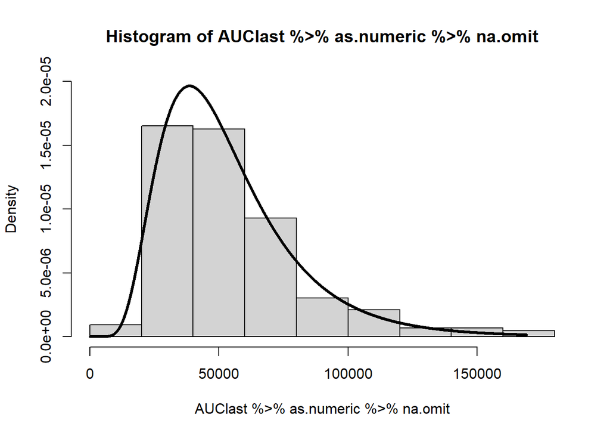

```r
with(nca_pk_dat_160, {
  x <- AUClast %>% as.numeric %>% na.omit
  hist(AUClast %>% as.numeric %>% na.omit, freq=F, ylim=c(0, 2e-5))
  fit<-fitdistr(x,"log-normal")$estimate
  lines(dlnorm(0:max(x),fit[1],fit[2]), lwd=3)
  }
)
```

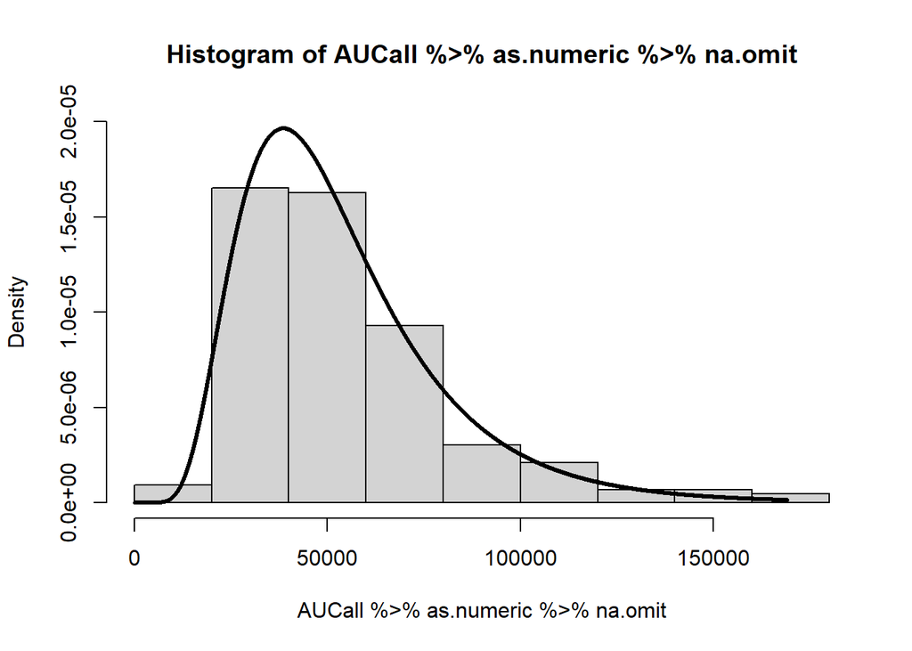

```r
nca_pk_dat_160$AUClast_log <- nca_pk_dat_160$AUClast %>% as.numeric %>% log

with(nca_pk_dat_160, {
  x <- AUCall %>% as.numeric %>% na.omit
  hist(AUCall %>% as.numeric %>% na.omit, freq=F, ylim=c(0, 2e-5))
  fit<-fitdistr(x,"log-normal")$estimate
  lines(dlnorm(0:max(x),fit[1],fit[2]), lwd=3)
  }
)
```

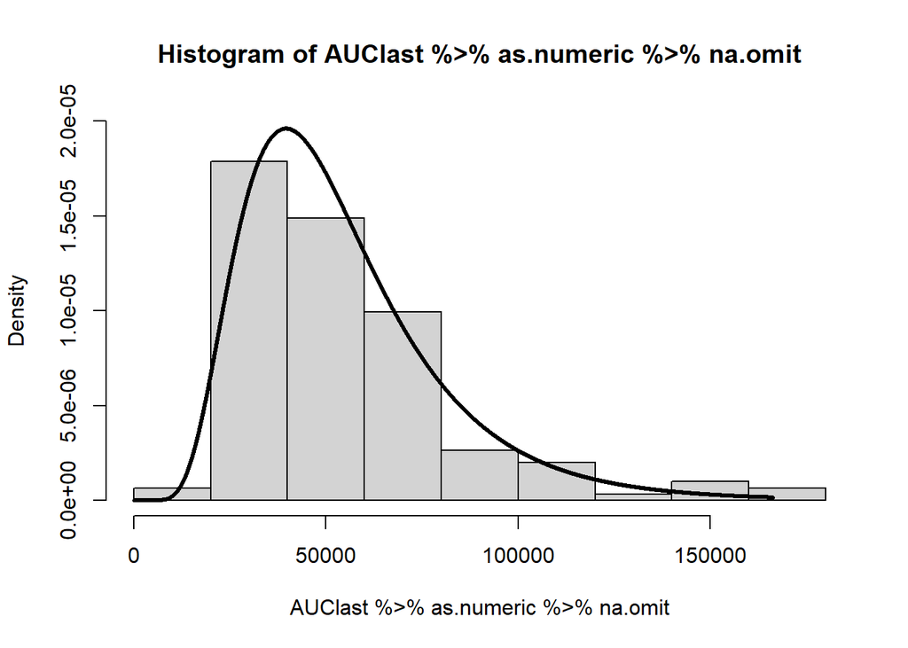

```r
nca_pk_dat_160$AUCall_log <- nca_pk_dat_160$AUCall %>% as.numeric %>% log

# self derived data
with(auclast_anh , {
  x <- AUClast %>% as.numeric %>% na.omit
  hist(AUClast %>% as.numeric %>% na.omit, freq=F, ylim=c(0, 2e-5))
  fit<-fitdistr(x,"log-normal")$estimate
  lines(dlnorm(0:max(x),fit[1],fit[2]), lwd=3)
  }
)
```

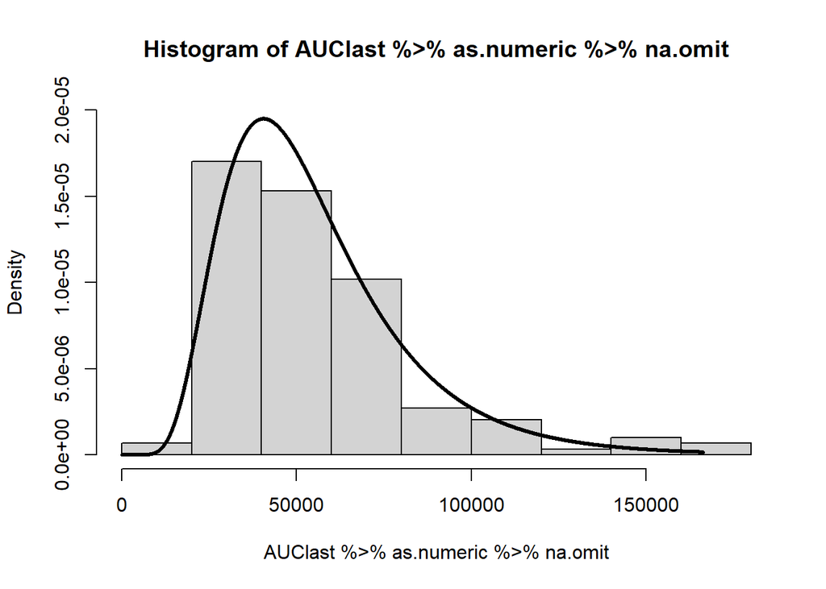

```r
auclast_anh$AUClast_log <- auclast_anh$AUClast %>% log


with(auclast_anh_fasted , {
  x <- AUClast %>% as.numeric %>% na.omit
  hist(AUClast %>% as.numeric %>% na.omit, freq=F, ylim=c(0, 2e-5))
  fit<-fitdistr(x,"log-normal")$estimate
  lines(dlnorm(0:max(x),fit[1],fit[2]), lwd=3)
  }
)
```

```r
auclast_anh_fasted$AUClast_log <- auclast_anh_fasted$AUClast %>% log
```

**Estimate CV**

```r
tmp_anova <- aov(AUClast_log ~ USUBJID, data = nca_pk_dat_160)
mse       <- (tmp_anova$residuals ^ 2 %>% sum) / tmp_anova$df.residual

(cv_auclast_log <- mse2CV(mse))
```

```
## [1] 0.2194621
```

```r
# repeat for AUCIINF_pred
tmp_anova <- aov(AUCall_log ~ USUBJID, data = nca_pk_dat_160)
mse       <- (tmp_anova$residuals ^ 2 %>% sum) / tmp_anova$df.residual

(cv_aucall_log <- mse2CV(mse))
```

```
## [1] 0.2194621
```

```r
# repeat for self-derived AUClast
tmp_anova2 <- aov(AUClast_log ~ USUBJID, data = auclast_anh)
mse2       <- (tmp_anova2$residuals ^ 2 %>% sum) / tmp_anova2$df.residual

(cv_auclast_log2 <- mse2CV(mse2))
```

```
## [1] 0.2381844
```

```r
tmp_anova2_fasted <- aov(AUClast_log ~ USUBJID, data = auclast_anh_fasted)
mse2_fasted       <- (tmp_anova2_fasted$residuals ^ 2 %>% sum) / tmp_anova2_fasted$df.residual

(cv_auclast_log2_fasted <- mse2CV(mse2_fasted))
```

```
## [1] 0.2333941
```

### 0.4.4 Estimate $C_{\max}$

**Estimation**

```r
cmax_anh <- pc160 %>% group_by(USUBJID, PCRFTDTC_Date) %>% summarise(Cmax=PCSTRESN[PCTPT!='PRE-DOSE'] %>% max(na.rm = T), VISIT=VISIT[PCTPT!='PRE-DOSE'] %>%unique)
cmax_anh$Cycle <- sapply(cmax_anh$VISIT, FUN = function(x) {
  case_when(
    x %>% grepl(x=., pattern='Fed Day') ~ 1,
    x %>% grepl(x=., pattern='Cycle 1') ~ 1,
    x %>% grepl(x=., pattern='Cycle 2') ~ 2,
    x %>% grepl(x=., pattern='Cycle 3') ~ 3,
    x %>% grepl(x=., pattern='Cycle 4') ~ 4
  )
})

cmax_anh$Day <- sapply(cmax_anh$VISIT, FUN = function(x) {
  case_when(
    x %>% grepl(x=., pattern='Fed Day') ~ -3,
    x %>% grepl(x=., pattern='Day 1') ~ 1,
    x %>% grepl(x=., pattern='Day 2') ~ 2,
    x %>% grepl(x=., pattern='Day 3') ~ 3,
    x %>% grepl(x=., pattern='Day 4') ~ 4,
    x %>% grepl(x=., pattern='Day 5') ~ 5
  )
})

cmax_anh_fasted <- pc160_fasted %>% group_by(USUBJID, PCRFTDTC_Date) %>% summarise(Cmax=PCSTRESN[PCTPT!='PRE-DOSE'] %>% max(na.rm = T), VISIT=VISIT[PCTPT!='PRE-DOSE'] %>%unique)
cmax_anh_fasted$Cycle <- sapply(cmax_anh_fasted$VISIT, FUN = function(x) {
  case_when(
    x %>% grepl(x=., pattern='Fed Day') ~ 1,
    x %>% grepl(x=., pattern='Cycle 1') ~ 1,
    x %>% grepl(x=., pattern='Cycle 2') ~ 2,
    x %>% grepl(x=., pattern='Cycle 3') ~ 3,
    x %>% grepl(x=., pattern='Cycle 4') ~ 4
  )
})

cmax_anh_fasted$Day <- sapply(cmax_anh_fasted$VISIT, FUN = function(x) {
  case_when(
    x %>% grepl(x=., pattern='Fed Day') ~ -3,
    x %>% grepl(x=., pattern='Day 1') ~ 1,
    x %>% grepl(x=., pattern='Day 2') ~ 2,
    x %>% grepl(x=., pattern='Day 3') ~ 3,
    x %>% grepl(x=., pattern='Day 4') ~ 4,
    x %>% grepl(x=., pattern='Day 5') ~ 5
  )
})
```

**Check if data is normally or log-normally distributed**

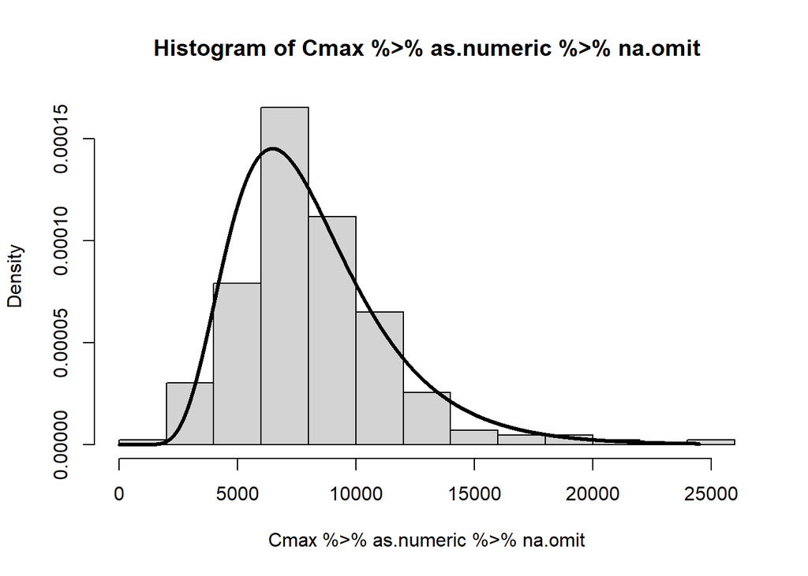

```r
# Roche PK team derived data
with(nca_pk_dat_160, {
  x <- Cmax %>% as.numeric %>% na.omit
  hist(Cmax %>% as.numeric %>% na.omit, freq=F)
  fit<-fitdistr(x,"log-normal")$estimate
  lines(dlnorm(0:max(x),fit[1],fit[2]), lwd=3)
  }
)
```

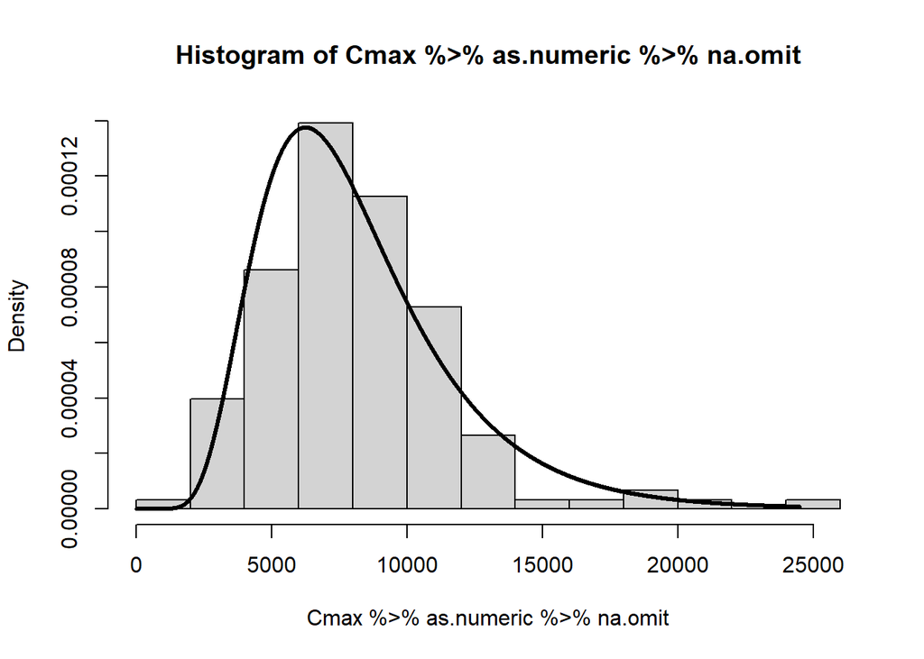

```r
nca_pk_dat_160$Cmax_log <- nca_pk_dat_160$Cmax %>% as.numeric %>% log

# Anh's derivation
with(cmax_anh, {
  x <- Cmax %>% as.numeric %>% na.omit
  hist(Cmax %>% as.numeric %>% na.omit, freq=F)
  fit<-fitdistr(x,"log-normal")$estimate
  lines(dlnorm(0:max(x),fit[1],fit[2]), lwd=3)
  }
)
```

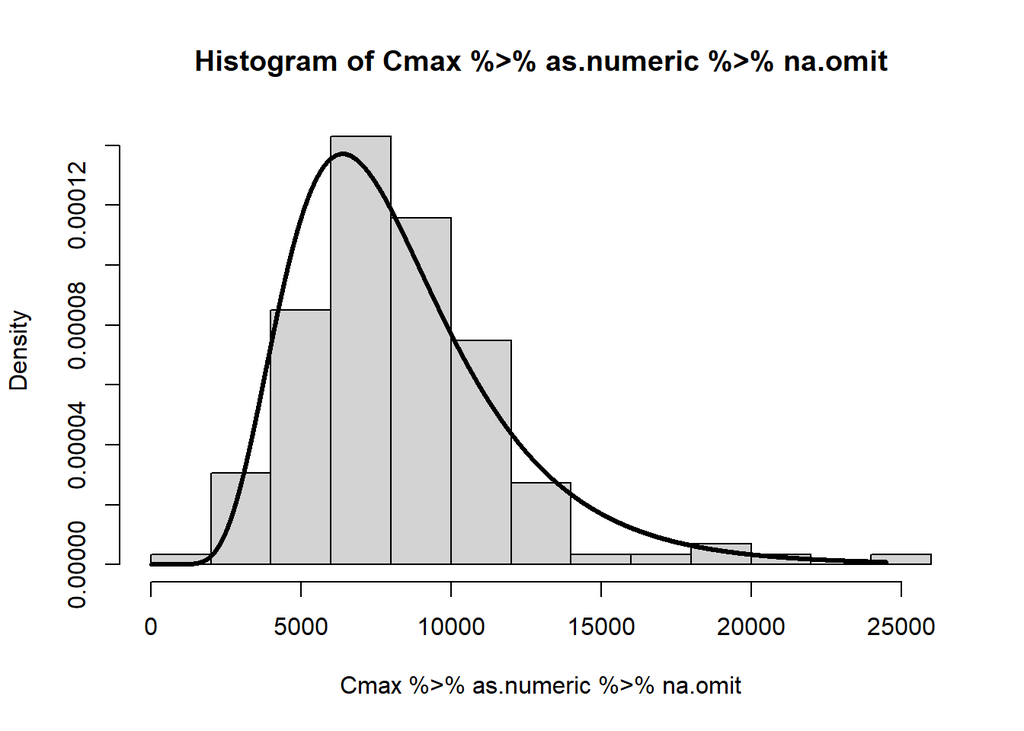

```r
cmax_anh$Cmax_log <- cmax_anh$Cmax %>% as.numeric %>% log


with(cmax_anh_fasted, {
  x <- Cmax %>% as.numeric %>% na.omit
  hist(Cmax %>% as.numeric %>% na.omit, freq=F)
  fit<-fitdistr(x,"log-normal")$estimate
  lines(dlnorm(0:max(x),fit[1],fit[2]), lwd=3)
  }
)
```

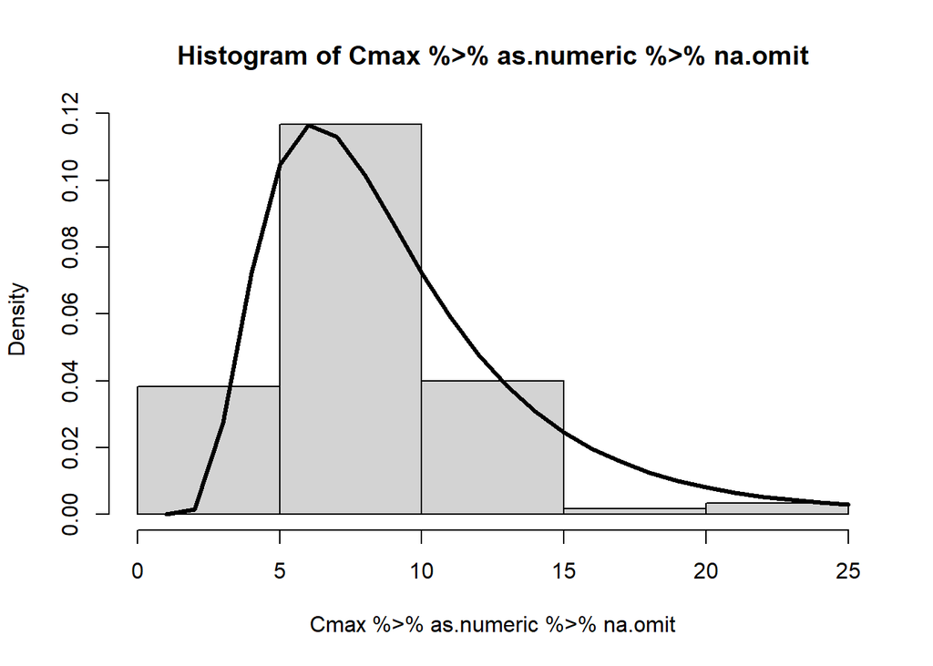

```r
cmax_anh_fasted$Cmax_log <- cmax_anh_fasted$Cmax %>% as.numeric %>% log


# Repare derived data
with(nca_pk_dat_repare_160, {
  x <- Cmax %>% as.numeric %>% na.omit
  hist(Cmax %>% as.numeric %>% na.omit, freq=F)
  fit<-fitdistr(x,"log-normal")$estimate
  lines(dlnorm(0:max(x),fit[1],fit[2]), lwd=3)
  }
)
```

```r
nca_pk_dat_repare_160$Cmax_log <- nca_pk_dat_repare_160$Cmax %>% as.numeric %>% log

# compare Anh's drivation vs Repare's
tmp <- cmax_anh #%>% filter(USUBJID %in% (nca_pk_dat_repare_160$USUBJID %>% unique))

tmp_join <-
inner_join(x=tmp %>% dplyr::select(USUBJID, PCRFTDTC_Date, Cmax, Cycle, Day), y=nca_pk_dat_repare_160 %>% dplyr::select(USUBJID, Cycle, Day, Cmax), by = c('USUBJID', 'Cycle', 'Day'))

tmp_join %>% kable
```

| USUBJID | PCRFTDTC_Date | Cmax.x | Cycle | Day | Cmax.y |
| --- | --- | --- | --- | --- | --- |
| RP-3500-01-1001-0032 | 2021-03-11 | 3940 | 1 | -3 | 3.94 |
| RP-3500-01-1001-0032 | 2021-03-15 | 6340 | 1 | 1 | 6.34 |
| RP-3500-01-1001-0059 | 2021-04-02 | 5340 | 1 | -3 | 5.34 |
| RP-3500-01-1001-0059 | 2021-04-05 | 9790 | 1 | 1 | 9.7899999999999991 |
| RP-3500-01-1001-0062 | 2021-04-15 | 3650 | 1 | -3 | 3.65 |
| RP-3500-01-1001-0062 | 2021-04-19 | 12200 | 1 | 1 | 12.2 |
| RP-3500-01-1001-0092 | 2021-07-22 | 9760 | 2 | 3 | 9.76 |
| RP-3500-01-1001-0146 | 2021-07-16 | 6420 | 2 | 3 | 6.42 |
| RP-3500-01-1001-0150 | 2021-07-02 | 3170 | 1 | 3 | 3.17 |
| RP-3500-01-1001-0150 | 2021-07-23 | 4360 | 2 | 3 | 4.3600000000000003 |
| RP-3500-01-1001-0154 | 2021-07-02 | 5870 | 2 | 3 | 5.87 |
| RP-3500-01-1001-0175 | 2021-07-07 | 7730 | 1 | 1 | 7.73 |
| RP-3500-01-1001-0175 | 2021-07-09 | 9340 | 1 | 3 | 9.34 |
| RP-3500-01-1001-0175 | 2021-07-30 | 4490 | 2 | 3 | 4.49 |
| RP-3500-01-1001-0213 | 2021-07-27 | 6550 | 1 | 1 | 6.55 |
| RP-3500-01-1001-0213 | 2021-07-29 | 4680 | 1 | 3 | 4.68 |
| RP-3500-01-1001-0213 | 2021-08-19 | 10400 | 2 | 3 | 10.4 |
| RP-3500-01-1001-0219 | 2021-07-28 | 6230 | 1 | 1 | 6.23 |
| RP-3500-01-1001-0219 | 2021-07-30 | 7300 | 1 | 3 | 7.3 |
| RP-3500-01-1001-0254 | 2021-09-03 | 4910 | 1 | 1 | 4.91 |
| RP-3500-01-1001-0254 | 2021-09-05 | 4650 | 1 | 3 | 4.6500000000000004 |
| RP-3500-01-1001-0254 | 2021-10-04 | 8070 | 2 | 3 | 8.07 |
| RP-3500-01-1001-0277 | 2021-10-19 | 17400 | 1 | 1 | 17.399999999999999 |
| RP-3500-01-1001-0277 | 2021-10-21 | 24500 | 1 | 3 | 24.5 |
| RP-3500-01-1001-0277 | 2021-11-11 | 20700 | 2 | 3 | 20.7 |
| RP-3500-01-1002-0031 | 2021-02-12 | 5320 | 1 | 3 | 5.32 |
| RP-3500-01-1002-0031 | 2021-03-04 | 6750 | 2 | 3 | 6.75 |
| RP-3500-01-1002-0102 | 2021-05-18 | 7240 | 1 | 1 | 7.24 |
| RP-3500-01-1002-0102 | 2021-05-20 | 6490 | 1 | 3 | 6.49 |
| RP-3500-01-1002-0102 | 2021-06-10 | 3900 | 2 | 3 | 3.9 |

[output cut: 88 more lines]

**Estimate CV**

```r
# Roche PK team derived data
tmp_anova <- aov(Cmax_log ~ USUBJID, data = nca_pk_dat_160)
mse       <- (tmp_anova$residuals ^ 2 %>% sum) / tmp_anova$df.residual

(cv_cmax_log <- mse2CV(mse))
```

```
## [1] 0.268169
```

```r
# Anh team derived data
tmp_anova2 <- aov(Cmax_log ~ USUBJID, data = cmax_anh)
mse2       <- (tmp_anova2$residuals ^ 2 %>% sum) / tmp_anova2$df.residual

(cv_cmax_log2 <- mse2CV(mse2))
```

```
## [1] 0.2796847
```

```r
tmp_anova2_fasted <- aov(Cmax_log ~ USUBJID, data = cmax_anh_fasted)
mse2_fasted       <- (tmp_anova2_fasted$residuals ^ 2 %>% sum) / tmp_anova2_fasted$df.residual

(cv_cmax_log2_fasted <- mse2CV(mse2_fasted))
```

```
## [1] 0.2616837
```

```r
# For self-derived data and consider only pts appearing in repare's pk sets
tmp_anova3 <- aov(Cmax_log ~ USUBJID, data = cmax_anh %>% filter(USUBJID %in% (nca_pk_dat_repare_160$USUBJID %>% unique)) )
mse3       <- (tmp_anova3$residuals ^ 2 %>% sum) / tmp_anova3$df.residual

(cv_cmax_log3 <- mse2CV(mse3))
```

```
## [1] 0.2892663
```

```r
tmp_anova3_fasted <- aov(Cmax_log ~ USUBJID, data = cmax_anh_fasted %>% filter(USUBJID %in% (nca_pk_dat_repare_160$USUBJID %>% unique)) )
mse3_fasted       <- (tmp_anova3_fasted$residuals ^ 2 %>% sum) / tmp_anova3_fasted$df.residual

(cv_cmax_log3_fasted <- mse2CV(mse3_fasted))
```

```
## [1] 0.2672715
```

```r
# Repare derived data
tmp_anova <- aov(Cmax_log ~ USUBJID, data = nca_pk_dat_repare_160 #%>%filter(USUBJID!='RP-3500-01-1001-0007')
                 )
mse       <- (tmp_anova$residuals ^ 2 %>% sum) / tmp_anova$df.residual

(cv_cmax_log_repare <- mse2CV(mse))
```

```
## [1] 0.2892735
```

```r
# using the joint data set
tmp_anova4 <- aov(I(Cmax.x %>% log) ~ USUBJID, data = tmp_join)
mse4       <- (tmp_anova4$residuals ^ 2 %>% sum) / tmp_anova4$df.residual

(cv_cmax_log4 <- mse2CV(mse4))
```

```
## [1] 0.2913464
```

```r
tmp_anova5 <- aov(I((Cmax.y %>% as.numeric)%>%log) ~ USUBJID, data = tmp_join %>% filter(!USUBJID %in% c('RP-3500-01-3003-0217', 'RP-3500-01-1001-0007')))
mse5       <- (tmp_anova5$residuals ^ 2 %>% sum) / tmp_anova5$df.residual

(cv_cmax_log5 <- mse2CV(mse5))
```

```
## [1] 0.2913496
```

### 0.4.5 Estimate $C_{\text{last}}$

**Estimation**

```r
cvlast_anh <- pc160 %>% group_by(USUBJID, PCRFTDTC_Date) %>% summarise(Clast=PCSTRESN[PCTPT!='PRE-DOSE'] %>% na.omit %>% tail(1))
cvlast_anh_fasted <- pc160_fasted %>% group_by(USUBJID, PCRFTDTC_Date) %>% summarise(Clast=PCSTRESN[PCTPT!='PRE-DOSE'] %>% na.omit %>% tail(1))
```

**Check if data is normally or log-normally distributed**

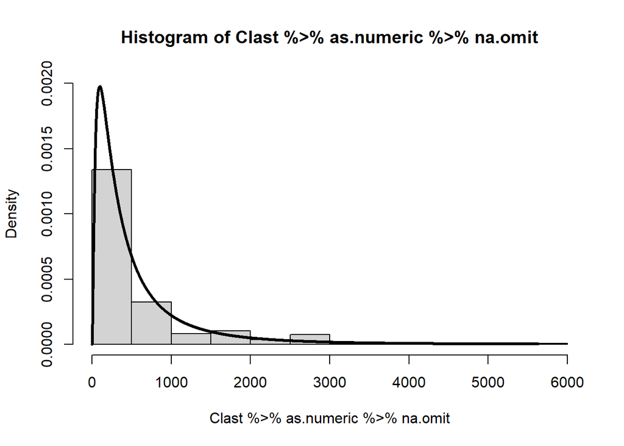

```r
with(nca_pk_dat_160, {
  x <- Clast %>% as.numeric %>% na.omit
  hist(Clast %>% as.numeric %>% na.omit, freq=F, ylim=c(0,20e-4))
  fit<-fitdistr(x,"log-normal")$estimate
  lines(dlnorm(0:max(x),fit[1],fit[2]), lwd=3)
  }
)
```

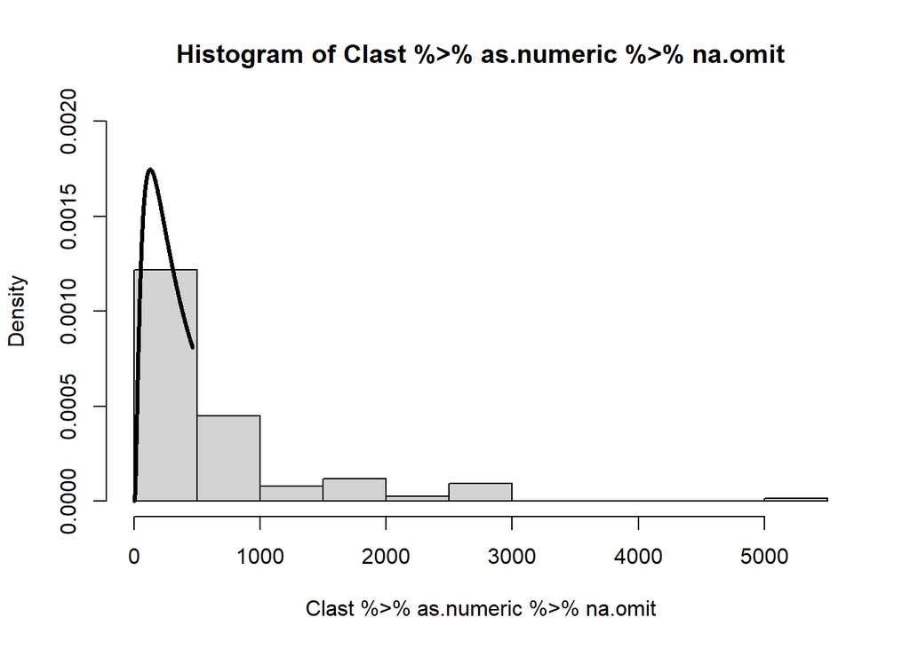

```r
nca_pk_dat_160$Clast_log <- nca_pk_dat_160$Clast %>% as.numeric %>% log

# Anh's derivation
with(cvlast_anh, {
  x <- Clast %>% as.numeric %>% na.omit
  hist(Clast %>% as.numeric %>% na.omit, freq=F, ylim=c(0,20e-4))
  fit<-fitdistr(x,"log-normal")$estimate
  lines(dlnorm(0:last(x),fit[1],fit[2]), lwd=3)
  }
)
```

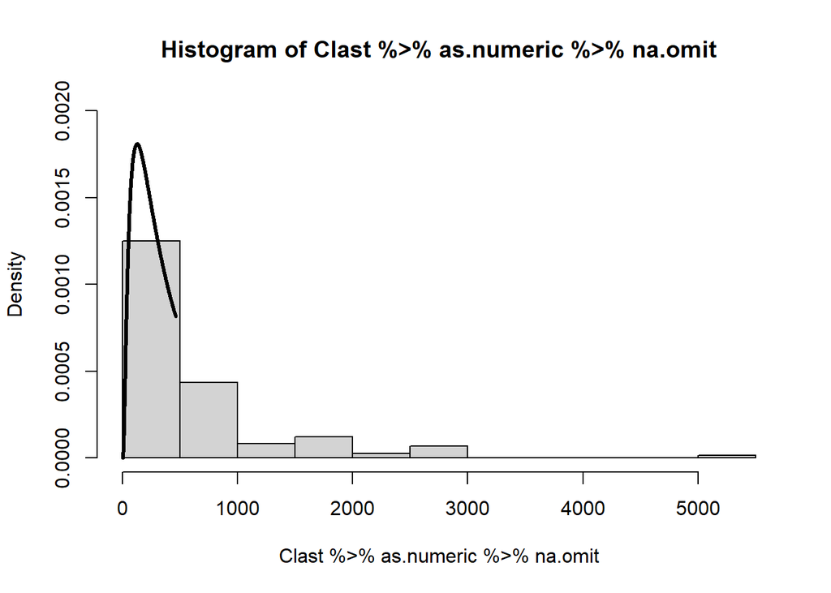

```r
cvlast_anh$Clast_log <- cvlast_anh$Clast %>% as.numeric %>% log


with(cvlast_anh_fasted, {
  x <- Clast %>% as.numeric %>% na.omit
  hist(Clast %>% as.numeric %>% na.omit, freq=F, ylim=c(0,20e-4))
  fit<-fitdistr(x,"log-normal")$estimate
  lines(dlnorm(0:last(x),fit[1],fit[2]), lwd=3)
  }
)
```

```r
cvlast_anh_fasted$Clast_log <- cvlast_anh_fasted$Clast %>% as.numeric %>% log
```

**Estimate CV**

```r
tmp_anova <- aov(Clast_log ~ USUBJID, data = nca_pk_dat_160)
mse       <- (tmp_anova$residuals ^ 2 %>% sum) / tmp_anova$df.residual

(cv_clast_log <- mse2CV(mse))
```

```
## [1] 0.713246
```

```r
tmp_anova2 <- aov(Clast_log ~ USUBJID, data = cvlast_anh)
mse2       <- (tmp_anova2$residuals ^ 2 %>% sum) / tmp_anova2$df.residual

(cv_clast_log2 <- mse2CV(mse2))
```

```
## [1] 0.6348735
```

```r
tmp_anova2_fasted <- aov(Clast_log ~ USUBJID, data = cvlast_anh_fasted)
mse2_fasted       <- (tmp_anova2_fasted$residuals ^ 2 %>% sum) / tmp_anova2_fasted$df.residual

(cv_clast_log2_fasted <- mse2CV(mse2_fasted))
```

```
## [1] 0.6024599
```

## 0.5 Sample Size Estimation

### 0.5.1 Requirements

```r
target_power <- .8 #.85, .9
theta0      <- .95 #.9
alpha       <- .1

log_scale <- T

CVs <- c('aucinf_obs_log' = cv_aucinf_obs_log,
         'aucinf_pred_log' = cv_aucinf_pred_log,
         'aucinf_obs_log2' = cv_aucinf_obs_log2,
         'aucinf_obs_log2_fasted' = cv_aucinf_obs_log2_fasted,
         'aucinf_obs_log3' = cv_aucinf_obs_log3,
         'aucinf_obs_log3_fasted' = cv_aucinf_obs_log3_fasted,
         'aucinf_obs_log_repare'  = cv_aucinf_obs_log_repare,
         'aucall_log' = cv_aucall_log,
         'auclast_log' = cv_auclast_log,
         'auclast_log2' = cv_auclast_log2,
         'auclast_log2_fasted' = cv_auclast_log2_fasted,
         'cmax_log' = cv_cmax_log,
         'cmax_log2' = cv_cmax_log2,
         'cmax_log2_fasted' = cv_cmax_log2_fasted,
         'cmax_log3' = cv_cmax_log3,
         'cmax_log3_fasted' = cv_cmax_log3_fasted,
         'cmax_log_repare' = cv_cmax_log_repare,
         'cmax_log5'=cv_cmax_log5,
         'clast_log' = cv_clast_log,
         'nominal' = .27)

N_total_2x2 <- sapply(CVs, function(x) {
    sampleN.TOST(CV = x, alpha = alpha, targetpower = target_power, theta0=theta0, logscale = log_scale, design = '2x2', method = 'exact', robust = T, print = F)$`Sample size`
}) # "robust" is not relevant for 2x2 design

N_total_3x3 <- sapply(CVs, function(x) {
    sampleN.TOST(CV = x, alpha = alpha, targetpower = target_power, theta0=theta0, logscale = log_scale, design = '3x3', method = 'exact', robust = T, print = F)$`Sample size`
}) # for 3x3 "robust" to T tends to give  slightly larger sample size

# Print results
tmp_tab <-
rbind(
  CVs,
  'N_total_2x2' = N_total_2x2,
  'N_total_3x3' = N_total_3x3
) %>% t

rownames(tmp_tab) <- CVs %>% names
tmp_tab %>% kable()
```

|  | CVs | N_total_2x2 | N_total_3x3 |
| --- | --- | --- | --- |
| aucinf_obs_log | 0.1817233 | 12 | 12 |
| aucinf_pred_log | 0.1820314 | 12 | 12 |
| aucinf_obs_log2 | 0.1906130 | 14 | 15 |
| aucinf_obs_log2_fasted | 0.1924430 | 14 | 15 |
| aucinf_obs_log3 | 0.1966822 | 14 | 15 |
| aucinf_obs_log3_fasted | 0.1991790 | 14 | 15 |
| aucinf_obs_log_repare | 0.1920000 | 14 | 15 |
| aucall_log | 0.2194621 | 18 | 18 |
| auclast_log | 0.2194621 | 18 | 18 |
| auclast_log2 | 0.2381844 | 20 | 21 |
| auclast_log2_fasted | 0.2333941 | 18 | 18 |
| cmax_log | 0.2681690 | 24 | 24 |
| cmax_log2 | 0.2796847 | 26 | 27 |
| cmax_log2_fasted | 0.2616837 | 24 | 24 |
| cmax_log3 | 0.2892663 | 28 | 27 |
| cmax_log3_fasted | 0.2672715 | 24 | 24 |
| cmax_log_repare | 0.2892735 | 28 | 27 |
| cmax_log5 | 0.2913496 | 28 | 30 |
| clast_log | 0.7132460 | 134 | 135 |
| nominal | 0.2700000 | 24 | 24 |

## 0.6 Power for 24 Subjects and Various BE Margins and CV of 0.27

```r
theta1 <- c(.8, .775, .75, .725, .7)
theta2 <- 1/theta1
maxCV  <- .27 # as written in protocol #CVs[CVs<=.5] %>% max
n <- 24
pows <-
sapply(theta1, function(x) power.TOST(CV = maxCV, alpha = alpha, n=n, theta0=theta0, theta1=x, logscale = log_scale, design = '3x3', method = 'exact', robust = T))

cbind('low'=theta1, 'upp'=theta2, 'pow'=pows) %>% kable(digits = 3, row.names = F, caption = paste0('Power for various BE interval for ', n, ' subjects and', ' CV=', maxCV))
```

Power for various BE interval for 24 subjects and CV=0.27

| low | upp | pow |
| --- | --- | --- |
| 0.800 | 1.250 | 0.808 |
| 0.775 | 1.290 | 0.903 |
| 0.750 | 1.333 | 0.958 |
| 0.725 | 1.379 | 0.985 |
| 0.700 | 1.429 | 0.996 |